**Kernel Author:**  
[Bhishan Poudel, Ph.D Astrophysics](https://bhishanpdl.github.io/) .

# Description

In this project we will use multiclass classification to predict one of the 8 possible value of Response.

The data is taken from Kaggle Prudential Life Insurance Project.

About only 40% household in USA has life insurance policy. Based on different of applicant 8 different quotes are granted to applicants.

Here category 8 has the highest counts, I assume it the quote that is granted.

```
Records: 60k
Features: 127
Target: Response (has 8 categories, 1-8)
```

Features:

```
1 Misc             : Age ht wt bmi              4
2 Product Info     : Product_Info_1 to 7        7
3 Employment Info  : Employment_Info_1 to 6     6
4 Insured Info     : InsuredInfo_1 to 7         7
5 Insurance History: Insurance_History_1 to 9   9
6 Family History   : Family_Hist_1 to 5         5
7 Medical History  : Medical_History_1 to 41    41
8 Medical Keywords : Medical_Keyword_1 to 48    48
Target: Response                                1
ID    : ID                                      1
---------------------------------------------------
Total Features: 127
Dependent Variable: 1 (Response)
```

# Imports

```python
import numpy as np
import pandas as pd
import seaborn as sns
sns.set(color_codes=True)

import matplotlib
import matplotlib.pyplot as plt
%matplotlib inline

import os
import time

# random state
SEED=100
np.random.seed(SEED) # we need this in each cell

# Jupyter notebook settings for pandas
pd.set_option('display.max_columns', 200)
pd.set_option('display.max_rows', 100) # None for all the rows
pd.set_option('display.max_colwidth', 50)

print([(x.__name__,x.__version__) for x in [np, pd,sns,matplotlib]])
```

```
[('numpy', '1.18.5'), ('pandas', '1.0.4'), ('seaborn', '0.10.1'), ('matplotlib', '3.2.1')]
```

```python
import scipy
from scipy import stats
```

```python
import IPython
from IPython.display import display
```

```python
from sklearn.preprocessing import MinMaxScaler, StandardScaler, RobustScaler
```

```python
# Google colab
```

```python
%%capture
# capture will not print in notebook

import os
import sys
ENV_COLAB = 'google.colab' in sys.modules

if ENV_COLAB:
    ### mount google drive
    from google.colab import drive
    drive.mount('/content/drive')

    ### load the data dir
    dat_dir = 'drive/My Drive/Colab Notebooks/data/'
    sys.path.append(dat_dir)

    ### Image dir
    img_dir = 'drive/My Drive/Colab Notebooks/images/'
    if not os.path.isdir(img_dir): os.makedirs(img_dir)
    sys.path.append(img_dir)

    ### Output dir
    out_dir = 'drive/My Drive/Colab Notebooks/outputs/'
    if not os.path.isdir(out_dir): os.makedirs(out_dir)
    sys.path.append(out_dir)

    ### Also install my custom module
    module_dir = 'drive/My Drive/Colab Notebooks/Bhishan_Modules/'
    sys.path.append(module_dir)
    !cd drive/My Drive/Colab Notebooks/Bhishan_Modules/
    !pip install -e bhishan
    !cd -

    #### print
    print('Environment: Google Colaboratory.')

# NOTE: If we update modules in gcolab, we need to restart runtime.
```

```python
import bhishan
from bhishan import bp

print(bhishan.__version__)
```

```
0.3.1
```

```python
%load_ext autoreload
```

```
The autoreload extension is already loaded. To reload it, use:
  %reload_ext autoreload
```

```python
%autoreload 2
```

```python
%%javascript
IPython.OutputArea.auto_scroll_threshold = 9999
```

```python
pd.set_option('max_columns',200)
pd.set_option('max_rows',200)
```

```python
import gc
gc.collect()
```

```
1241
```

```python
from tqdm import tqdm
import functools # funtools.lru_cache
```

```python
from sklearn.mixture import GaussianMixture
from sklearn.cluster import Birch
```

# Load the data

```python
df = pd.read_csv('https://github.com/bhishanpdl/Datasets/blob/master/Prudential_Insurance/raw/train.csv.zip?raw=true',compression='zip')
print(df.shape)
df.head()
```

```
(59381, 128)
```

|  | Id | Product_Info_1 | Product_Info_2 | Product_Info_3 | Product_Info_4 | Product_Info_5 | Product_Info_6 | Product_Info_7 | Ins_Age | Ht | Wt | BMI | Employment_Info_1 | Employment_Info_2 | Employment_Info_3 | Employment_Info_4 | Employment_Info_5 | Employment_Info_6 | InsuredInfo_1 | InsuredInfo_2 | InsuredInfo_3 | InsuredInfo_4 | InsuredInfo_5 | InsuredInfo_6 | InsuredInfo_7 | Insurance_History_1 | Insurance_History_2 | Insurance_History_3 | Insurance_History_4 | … |
| --- | --- | --- | --- | --- | --- | --- | --- | --- | --- | --- | --- | --- | --- | --- | --- | --- | --- | --- | --- | --- | --- | --- | --- | --- | --- | --- | --- | --- | --- | --- |
| 0 | 2 | 1 | D3 | 10 | 0.076923 | 2 | 1 | 1 | 0.641791 | 0.581818 | 0.148536 | 0.323008 | 0.028 | 12 | 1 | 0.0 | 3 | NaN | 1 | 2 | 6 | 3 | 1 | 2 | 1 | 1 | 1 | 3 | 1 | … |
| 1 | 5 | 1 | A1 | 26 | 0.076923 | 2 | 3 | 1 | 0.059701 | 0.600000 | 0.131799 | 0.272288 | 0.000 | 1 | 3 | 0.0 | 2 | 0.0018 | 1 | 2 | 6 | 3 | 1 | 2 | 1 | 2 | 1 | 3 | 1 | … |
| 2 | 6 | 1 | E1 | 26 | 0.076923 | 2 | 3 | 1 | 0.029851 | 0.745455 | 0.288703 | 0.428780 | 0.030 | 9 | 1 | 0.0 | 2 | 0.0300 | 1 | 2 | 8 | 3 | 1 | 1 | 1 | 2 | 1 | 1 | 3 | … |
| 3 | 7 | 1 | D4 | 10 | 0.487179 | 2 | 3 | 1 | 0.164179 | 0.672727 | 0.205021 | 0.352438 | 0.042 | 9 | 1 | 0.0 | 3 | 0.2000 | 2 | 2 | 8 | 3 | 1 | 2 | 1 | 2 | 1 | 1 | 3 | … |
| 4 | 8 | 1 | D2 | 26 | 0.230769 | 2 | 3 | 1 | 0.417910 | 0.654545 | 0.234310 | 0.424046 | 0.027 | 9 | 1 | 0.0 | 2 | 0.0500 | 1 | 2 | 6 | 3 | 1 | 2 | 1 | 2 | 1 | 1 | 3 | … |

```python
target = 'Response'
```

# Train-Test split with stratify

```python
from sklearn.model_selection import train_test_split

target = 'Response'

df_Xtrain_orig, df_Xtest, ser_ytrain_orig, ser_ytest = train_test_split(
    df.drop(target,axis=1), df[target],
    test_size=0.2, random_state=SEED, stratify=df[target])

df_Xtrain, df_Xvalid, ser_ytrain, ser_yvalid = train_test_split(
    df_Xtrain_orig, ser_ytrain_orig,
    test_size=0.2, random_state=SEED, stratify=ser_ytrain_orig)

print(f"df             : {df.shape}")

print(f"\ndf_Xtrain_orig : {df_Xtrain_orig.shape}")
print(f"ser_ytrain_orig: {ser_ytrain_orig.shape}")

print(f"\ndf_Xtrain      : {df_Xtrain.shape}")
print(f"ser_ytrain     : {ser_ytrain.shape}")

print(f"\ndf_Xvalid      : {df_Xvalid.shape}")
print(f"ser_yvalid     : {ser_yvalid.shape}")

print(f"\ndf_Xtest       : {df_Xtest.shape}")
print(f"ser_ytest      : {ser_ytest.shape}")

df_Xtrain_orig.head(2)
```

```
df             : (59381, 128)

df_Xtrain_orig : (47504, 127)
ser_ytrain_orig: (47504,)

df_Xtrain      : (38003, 127)
ser_ytrain     : (38003,)

df_Xvalid      : (9501, 127)
ser_yvalid     : (9501,)

df_Xtest       : (11877, 127)
ser_ytest      : (11877,)
```

|  | Id | Product_Info_1 | Product_Info_2 | Product_Info_3 | Product_Info_4 | Product_Info_5 | Product_Info_6 | Product_Info_7 | Ins_Age | Ht | Wt | BMI | Employment_Info_1 | Employment_Info_2 | Employment_Info_3 | Employment_Info_4 | Employment_Info_5 | Employment_Info_6 | InsuredInfo_1 | InsuredInfo_2 | InsuredInfo_3 | InsuredInfo_4 | InsuredInfo_5 | InsuredInfo_6 | InsuredInfo_7 | Insurance_History_1 | Insurance_History_2 | Insurance_History_3 | Insurance_History_4 | … |
| --- | --- | --- | --- | --- | --- | --- | --- | --- | --- | --- | --- | --- | --- | --- | --- | --- | --- | --- | --- | --- | --- | --- | --- | --- | --- | --- | --- | --- | --- | --- |
| 616 | 840 | 1 | A3 | 26 | 0.230769 | 2 | 3 | 1 | 0.059701 | 0.727273 | 0.225941 | 0.341911 | 0.03 | 9 | 1 | 0.0 | 2 | 0.015 | 1 | 2 | 3 | 3 | 1 | 1 | 1 | 2 | 1 | 1 | 3 | … |
| 3239 | 4322 | 1 | D3 | 26 | 0.230769 | 2 | 3 | 1 | 0.417910 | 0.654545 | 0.209205 | 0.376858 | 0.09 | 14 | 1 | 0.0 | 2 | 0.600 | 1 | 2 | 8 | 3 | 1 | 2 | 1 | 2 | 1 | 3 | 1 | … |

# Target Distribution

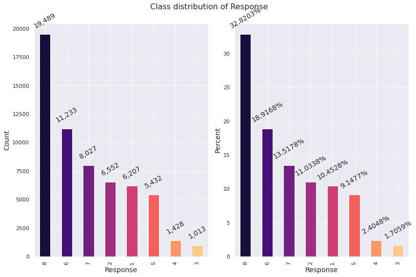

```python
df.bp.plot_cat(target)
```

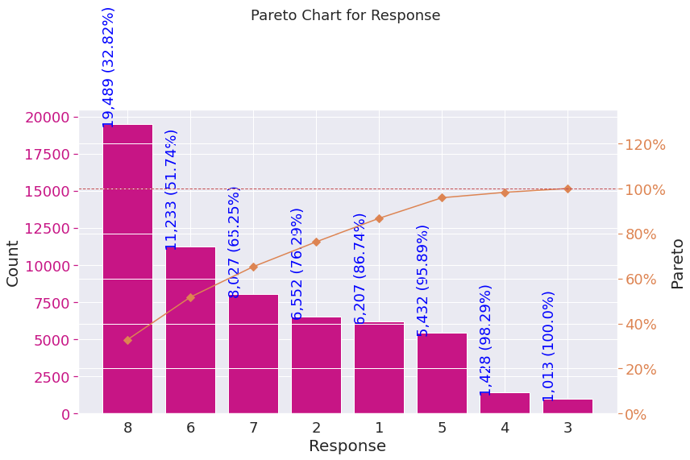

```python
df.bp.plot_pareto(target)
```

```python
"""
We can see class 8 has the highest distribution (33%), we can assume this as
the clean and accepted policy of insurance.

Other classes 1-7 can be assumed rejected or accepted with some conditions.


""";
```

```python
df_desc = df.bp.get_column_descriptions(transpose=True)
df_desc
```

|  | 47 | 69 | 61 | 52 | 37 | 35 | 34 | 29 | 36 | 17 | 38 | 15 | 12 | 91 | 87 | 116 | 113 | 96 | 122 | 92 | 98 | 124 | 83 | 80 | 95 | 97 | 90 | 119 | 86 | … |
| --- | --- | --- | --- | --- | --- | --- | --- | --- | --- | --- | --- | --- | --- | --- | --- | --- | --- | --- | --- | --- | --- | --- | --- | --- | --- | --- | --- | --- | --- | --- |
| Feature | Medical_History_10 | Medical_History_32 | Medical_History_24 | Medical_History_15 | Family_Hist_5 | Family_Hist_3 | Family_Hist_2 | Insurance_History_5 | Family_Hist_4 | Employment_Info_6 | Medical_History_1 | Employment_Info_4 | Employment_Info_1 | Medical_Keyword_13 | Medical_Keyword_9 | Medical_Keyword_38 | Medical_Keyword_35 | Medical_Keyword_18 | Medical_Keyword_44 | Medical_Keyword_14 | Medical_Keyword_20 | Medical_Keyword_46 | Medical_Keyword_5 | Medical_Keyword_2 | Medical_Keyword_17 | Medical_Keyword_19 | Medical_Keyword_12 | Medical_Keyword_41 | Medical_Keyword_8 | … |
| Type | float64 | float64 | float64 | float64 | float64 | float64 | float64 | float64 | float64 | float64 | float64 | float64 | float64 | int64 | int64 | int64 | int64 | int64 | int64 | int64 | int64 | int64 | int64 | int64 | int64 | int64 | int64 | int64 | int64 | … |
| Count | 59381 | 59381 | 59381 | 59381 | 59381 | 59381 | 59381 | 59381 | 59381 | 59381 | 59381 | 59381 | 59381 | 59381 | 59381 | 59381 | 59381 | 59381 | 59381 | 59381 | 59381 | 59381 | 59381 | 59381 | 59381 | 59381 | 59381 | 59381 | 59381 | … |
| Unique | 103 | 95 | 227 | 241 | 90 | 90 | 68 | 2265 | 68 | 992 | 171 | 871 | 1936 | 2 | 2 | 2 | 2 | 2 | 2 | 2 | 2 | 2 | 2 | 2 | 2 | 2 | 2 | 2 | 2 | … |
| Missing | 58824 | 58274 | 55580 | 44596 | 41811 | 34241 | 28656 | 25396 | 19184 | 10854 | 8889 | 6779 | 19 | 0 | 0 | 0 | 0 | 0 | 0 | 0 | 0 | 0 | 0 | 0 | 0 | 0 | 0 | 0 | 0 | … |
| MissingPct | 99.060000 | 98.140000 | 93.600000 | 75.100000 | 70.410000 | 57.660000 | 48.260000 | 42.770000 | 32.310000 | 18.280000 | 14.970000 | 11.420000 | 0.030000 | 0.000000 | 0.000000 | 0.000000 | 0.000000 | 0.000000 | 0.000000 | 0.000000 | 0.000000 | 0.000000 | 0.000000 | 0.000000 | 0.000000 | 0.000000 | 0.000000 | 0.000000 | 0.000000 | … |
| Zeros | 75 | 744 | 769 | 2135 | 3 | 4 | 1 | 19 | 9 | 4042 | 4789 | 44659 | 3688 | 59027 | 58986 | 58975 | 58969 | 58936 | 58934 | 58915 | 58898 | 58877 | 58869 | 58850 | 58837 | 58829 | 58787 | 58784 | 58763 | … |
| ZerosPct | 0.130000 | 1.250000 | 1.300000 | 3.600000 | 0.010000 | 0.010000 | 0.000000 | 0.030000 | 0.020000 | 6.810000 | 8.060000 | 75.210000 | 6.210000 | 99.400000 | 99.330000 | 99.320000 | 99.310000 | 99.250000 | 99.250000 | 99.220000 | 99.190000 | 99.150000 | 99.140000 | 99.110000 | 99.080000 | 99.070000 | 99.000000 | 98.990000 | 98.960000 | … |
| count | 557.000000 | 1107.000000 | 3801.000000 | 14785.000000 | 17570.000000 | 25140.000000 | 30725.000000 | 33985.000000 | 40197.000000 | 48527.000000 | 50492.000000 | 52602.000000 | 59362.000000 | 59381.000000 | 59381.000000 | 59381.000000 | 59381.000000 | 59381.000000 | 59381.000000 | 59381.000000 | 59381.000000 | 59381.000000 | 59381.000000 | 59381.000000 | 59381.000000 | 59381.000000 | 59381.000000 | 59381.000000 | 59381.000000 | … |
| mean | 141.118492 | 11.965673 | 50.635622 | 123.760974 | 0.484635 | 0.497737 | 0.474550 | 0.001733 | 0.444890 | 0.361469 | 7.962172 | 0.006283 | 0.077582 | 0.005962 | 0.006652 | 0.006837 | 0.006938 | 0.007494 | 0.007528 | 0.007848 | 0.008134 | 0.008488 | 0.008622 | 0.008942 | 0.009161 | 0.009296 | 0.010003 | 0.010054 | 0.010407 | … |
| std | 107.759559 | 38.718774 | 78.149069 | 98.516206 | 0.129200 | 0.140187 | 0.154959 | 0.007338 | 0.163012 | 0.349551 | 13.027697 | 0.032816 | 0.082347 | 0.076981 | 0.081289 | 0.082405 | 0.083007 | 0.086244 | 0.086436 | 0.088239 | 0.089821 | 0.091737 | 0.092456 | 0.094141 | 0.095275 | 0.095967 | 0.099515 | 0.099764 | 0.101485 | … |
| min | 0.000000 | 0.000000 | 0.000000 | 0.000000 | 0.000000 | 0.000000 | 0.000000 | 0.000000 | 0.000000 | 0.000000 | 0.000000 | 0.000000 | 0.000000 | 0.000000 | 0.000000 | 0.000000 | 0.000000 | 0.000000 | 0.000000 | 0.000000 | 0.000000 | 0.000000 | 0.000000 | 0.000000 | 0.000000 | 0.000000 | 0.000000 | 0.000000 | 0.000000 | … |
| 25% | 8.000000 | 0.000000 | 1.000000 | 17.000000 | 0.401786 | 0.401961 | 0.362319 | 0.000400 | 0.323944 | 0.060000 | 2.000000 | 0.000000 | 0.035000 | 0.000000 | 0.000000 | 0.000000 | 0.000000 | 0.000000 | 0.000000 | 0.000000 | 0.000000 | 0.000000 | 0.000000 | 0.000000 | 0.000000 | 0.000000 | 0.000000 | 0.000000 | 0.000000 | … |
| 50% | 229.000000 | 0.000000 | 8.000000 | 117.000000 | 0.508929 | 0.519608 | 0.463768 | 0.000973 | 0.422535 | 0.250000 | 4.000000 | 0.000000 | 0.060000 | 0.000000 | 0.000000 | 0.000000 | 0.000000 | 0.000000 | 0.000000 | 0.000000 | 0.000000 | 0.000000 | 0.000000 | 0.000000 | 0.000000 | 0.000000 | 0.000000 | 0.000000 | 0.000000 | … |
| 75% | 240.000000 | 2.000000 | 64.000000 | 240.000000 | 0.580357 | 0.598039 | 0.579710 | 0.002000 | 0.563380 | 0.550000 | 9.000000 | 0.000000 | 0.100000 | 0.000000 | 0.000000 | 0.000000 | 0.000000 | 0.000000 | 0.000000 | 0.000000 | 0.000000 | 0.000000 | 0.000000 | 0.000000 | 0.000000 | 0.000000 | 0.000000 | 0.000000 | 0.000000 | … |
| max | 240.000000 | 240.000000 | 240.000000 | 240.000000 | 1.000000 | 1.000000 | 1.000000 | 1.000000 | 0.943662 | 1.000000 | 240.000000 | 1.000000 | 1.000000 | 1.000000 | 1.000000 | 1.000000 | 1.000000 | 1.000000 | 1.000000 | 1.000000 | 1.000000 | 1.000000 | 1.000000 | 1.000000 | 1.000000 | 1.000000 | 1.000000 | 1.000000 | 1.000000 | … |

## Create Binary Classification Variable

Here our target has 8 classes, looking the class distribution we see that class 8 has the highest counts, we can treat this as 1 and all others as 0.

```python
cond = df[target] == 8
df['Response8'] = np.where(cond,1,0)

df.filter(regex='Resp').head()
```

|  | Response | Response8 |
| --- | --- | --- |
| 0 | 8 | 1 |
| 1 | 4 | 0 |
| 2 | 8 | 1 |
| 3 | 8 | 1 |
| 4 | 8 | 1 |

# Feature Engineering

## Data Types

```python
df.shape
```

```
(59381, 129)
```

```python
df.select_dtypes('number').shape
```

```
(59381, 128)
```

```python
df.select_dtypes('object').head()
```

|  | Product_Info_2 |
| --- | --- |
| 0 | D3 |
| 1 | A1 |
| 2 | E1 |
| 3 | D4 |
| 4 | D2 |

```python
"""
One of the feature Product_Info_2 is object.
Create new features from this.

""";
```

```python
df['Product_Info_2_char'] = df['Product_Info_2'].str[0]
df['Product_Info_2_num'] = df['Product_Info_2'].str[1].astype(int)
```

```python
df.Product_Info_2_num.isna().sum() # it's good we dont have nans.
```

```
0
```

```python
df.filter(regex='_Info_2').head(2)
```

|  | Product_Info_2 | Employment_Info_2 | Product_Info_2_char | Product_Info_2_num |
| --- | --- | --- | --- | --- |
| 0 | D3 | 12 | D | 3 |
| 1 | A1 | 1 | A | 1 |

```python
df = df.drop('Product_Info_2',axis=1)
df.filter(regex='_Info_2').head(2)
```

|  | Employment_Info_2 | Product_Info_2_char | Product_Info_2_num |
| --- | --- | --- | --- |
| 0 | 12 | D | 3 |
| 1 | 1 | A | 1 |

## Continuous Variable: square, cube, multiplication

```python
"""
Some important continuous features:
- age bmi ht wt

"""

df['Ins_Age_sq'] = df['Ins_Age'] * df['Ins_Age']
df['Ht_sq'] = df['Ht'] * df['Ht']
df['Wt_sq'] = df['Wt'] * df['Wt']
df['BMI_sq'] = df['BMI'] * df['BMI']

df['Ins_Age_cu'] = df['Ins_Age'] * df['Ins_Age'] * df['Ins_Age']
df['Ht_cu'] = df['Ht'] * df['Ht'] * df['Ht']
df['Wt_cu'] = df['Wt'] * df['Wt'] * df['Wt']
df['BMI_cu'] = df['BMI'] * df['BMI'] * df['BMI']

df['Age_Ht'] = df['Ins_Age'] * df['Ht']
df['Age_Wt'] = df['Ins_Age'] * df['Wt']
df['Age_BMI'] = df['Ins_Age'] * df['BMI']
```

```python
df.iloc[:2,-10:]
```

|  | Ht_sq | Wt_sq | BMI_sq | Ins_Age_cu | Ht_cu | Wt_cu | BMI_cu | Age_Ht | Age_Wt | Age_BMI |
| --- | --- | --- | --- | --- | --- | --- | --- | --- | --- | --- |
| 0 | 0.338512 | 0.022063 | 0.104334 | 0.264351 | 0.196953 | 0.003277 | 0.033701 | 0.373406 | 0.095329 | 0.207304 |
| 1 | 0.360000 | 0.017371 | 0.074141 | 0.000213 | 0.216000 | 0.002289 | 0.020188 | 0.035821 | 0.007869 | 0.016256 |

## Continuous Variable: Quantile Binning

```python
def quantile_binning(ser):
    conditions = [
        (ser <= ser.quantile(0.25)),
        (ser > ser.quantile(0.25)) & (ser <= ser.quantile(0.75)),
        (ser > ser.quantile(0.75))]

    choices = ['low', 'medium', 'high']
    return np.select(conditions, choices)
```

```python
df['Age_cat'] = quantile_binning(df['Ins_Age'])
df['Ht_cat'] = quantile_binning(df['Ht'])
df['Wt_cat'] = quantile_binning(df['Wt'])
df['BMI_cat'] = quantile_binning(df['BMI'])
```

```python
quantile_cat = df.filter(regex='_cat$').columns.to_list()
print(quantile_cat)
df.filter(regex='_cat$').head(2)
```

```
['Age_cat', 'Ht_cat', 'Wt_cat', 'BMI_cat']
```

|  | Age_cat | Ht_cat | Wt_cat | BMI_cat |
| --- | --- | --- | --- | --- |
| 0 | high | low | low | low |
| 1 | low | low | low | low |

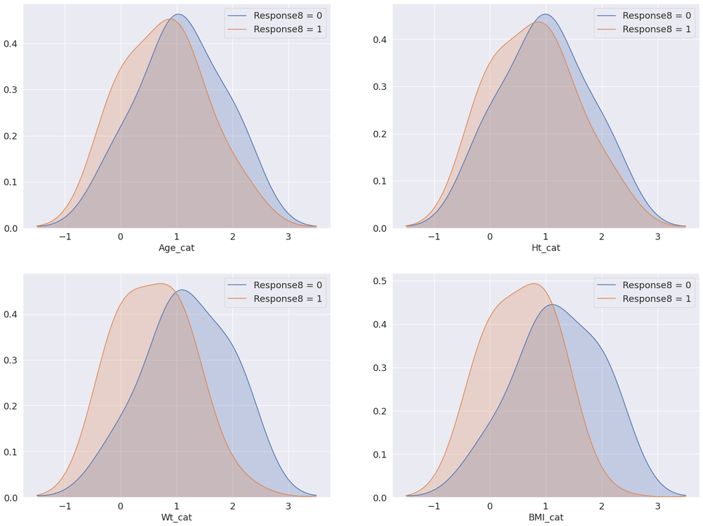

```python
df_resp8_0 = df.loc[df['Response8']==0]
df_resp8_1 = df.loc[df['Response8']==1]
mapping = {'low':0, 'medium':1,'high':2}
target8 = "Response8"

plt.figure()
fig, axes = plt.subplots(2,2,figsize=(24,18))
for i,col in enumerate(quantile_cat):
    i+=1
    plt.subplot(2,2,i)

    x0 = df_resp8_0[col].replace(mapping).to_numpy()
    x1 = df_resp8_1[col].replace(mapping).to_numpy()

    a = x0 / np.dot(x0,x0)
    b = x1 / np.dot(x1,x1)
    # overlap = np.dot(a,b)

    sns.kdeplot(x0, bw=0.5,label=f"{target8} = 0",shade=1)
    sns.kdeplot(x1, bw=0.5,label=f"{target8} = 1",shade=1)

    plt.xlabel(col, fontsize=18)
    plt.legend(loc='upper right',fontsize=18)
    plt.tick_params(axis='both', which='major', labelsize=18)
plt.show()
```

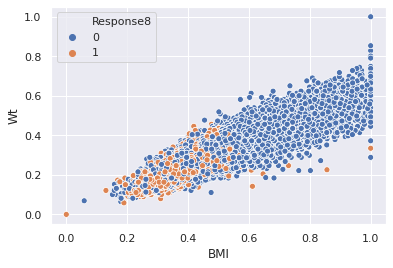

```python
sns.scatterplot(data=df,x='BMI',y='Wt',hue='Response8',alpha=1)
# when bmi is high and wt is high, applicant is most likely rejected.
```

```
==================================================
Feature: **BMI_cat**
Overall Count:
    medium: 50.04%
    low: 25.01%
    high: 24.94%

Total  **Response8_1** distribution:
    medium: 53.51%
    low: 45.08%
    high: 1.41%

Per BMI_cat  **Response8_1** distribution:
    low: 59.15%
    medium: 35.09%
    high: 1.86%
```

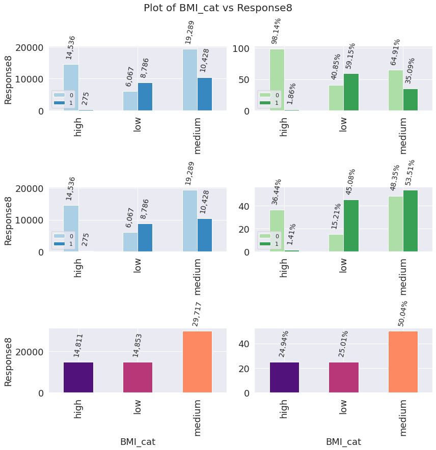

```python
# df.bp.plot_cat_cat('Age_cat','Response8')
# df.bp.plot_cat_cat('Ht_cat','Response8')
# df.bp.plot_cat_cat('Wt_cat','Response8')
df.bp.plot_cat_cat('BMI_cat','Response8')
```

```python
"""
Look at the top right figure.

Age: when age is high/medium ==> more rejection

Ht : when height_cat is not useful. for all category of ht, distribution is different.

Wt : Wt==high is important feature (almost all rejected)

BMI: bmi==high is important feature (almost all rejected)
""";
```

[output not shown]

```python
cat = 'BMI_cat'
df1 = df[[cat,'Response8']]
df1 = df1[df1[cat]=='high']
df1['Response8'].value_counts(normalize=True)
```

```
0    0.981433
1    0.018567
Name: Response8, dtype: float64
```

```python
pd.crosstab(df['BMI_cat'],df['Response8'],normalize='index')
```

| Response8 BMI_cat | 0 | 1 |
| --- | --- | --- |
| high | 0.981433 | 0.018567 |
| low | 0.408470 | 0.591530 |
| medium | 0.649090 | 0.350910 |

```python
df.filter(regex='_cat$').head(2)
```

|  | Age_cat | Ht_cat | Wt_cat | BMI_cat |
| --- | --- | --- | --- | --- |
| 0 | high | low | low | low |
| 1 | low | low | low | low |

```python
# when a feature is medium is medium, they may be less risky.
def risk_medium_bool(key):
    cond = (df[key] == 'medium')
    return np.where(cond,0,1)
```

```python
df['risk_Age_medium_bool'] = risk_medium_bool('Age_cat')
df['risk_Ht_medium_bool'] = risk_medium_bool('Ht_cat')
df['risk_Wt_medium_bool'] = risk_medium_bool('Wt_cat')
df['risk_BMI_medium_bool'] = risk_medium_bool('BMI_cat')
```

```python
def risk_at_least_one(key):
    cond = ((df['Age_cat'] == key) |
            (df['Ht_cat']  == key) |
            (df['Wt_cat']  == key) |
            (df['BMI_cat'] == key))

    return np.where(cond,1,0)
```

```python
df['risk_at_least_one_low'] = risk_at_least_one('low') # possible risk
df['risk_at_least_one_high'] = risk_at_least_one('high') # possible risk
```

```python
cond = ((df['Age_cat'] == 'high') |
        (df['Wt_cat']  == 'high') |
        (df['BMI_cat'] == 'high'))

df['risk_extreme'] = np.where(cond,1,0)
```

```python
df.filter(regex='_cat$|^risk_').head()
```

|  | Age_cat | Ht_cat | Wt_cat | BMI_cat | risk_Age_medium_bool | risk_Ht_medium_bool | risk_Wt_medium_bool | risk_BMI_medium_bool | risk_at_least_one_low | risk_at_least_one_high | risk_extreme |
| --- | --- | --- | --- | --- | --- | --- | --- | --- | --- | --- | --- |
| 0 | high | low | low | low | 1 | 1 | 1 | 1 | 1 | 1 | 1 |
| 1 | low | low | low | low | 1 | 1 | 1 | 1 | 1 | 0 | 0 |
| 2 | low | medium | medium | medium | 1 | 0 | 0 | 0 | 1 | 0 | 0 |
| 3 | low | medium | low | low | 1 | 0 | 1 | 1 | 1 | 0 | 0 |
| 4 | medium | low | medium | medium | 0 | 1 | 0 | 0 | 1 | 0 | 0 |

```python
cols_risk_bool = df.filter(regex='^risk_.*_bool$').columns.to_list()
cols_risk_bool
```

```
['risk_Age_medium_bool',
 'risk_Ht_medium_bool',
 'risk_Wt_medium_bool',
 'risk_BMI_medium_bool']
```

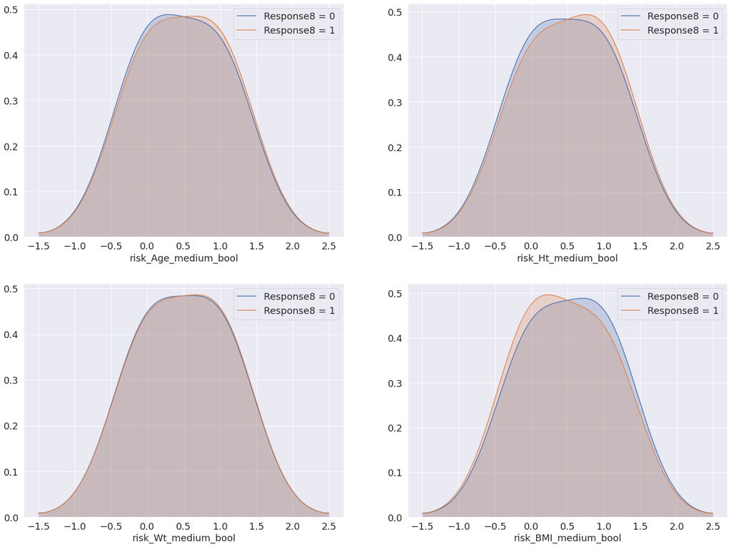

```python
df_resp8_0 = df.loc[df['Response8']==0]
df_resp8_1 = df.loc[df['Response8']==1]
target8 = "Response8"

plt.figure()
fig, axes = plt.subplots(2,2,figsize=(24,18))
for i,col in enumerate(cols_risk_bool):
    i+=1
    plt.subplot(2,2,i)

    x0 = df_resp8_0[col]
    x1 = df_resp8_1[col]

    sns.kdeplot(x0, bw=0.5,label=f"{target8} = 0",shade=1)
    sns.kdeplot(x1, bw=0.5,label=f"{target8} = 1",shade=1)

    plt.xlabel(col, fontsize=18)
    plt.legend(loc='upper right',fontsize=18)
    plt.tick_params(axis='both', which='major', labelsize=18)
plt.show()
```

```python
# risk_Age_medium_bool and risk_Wt_medium_bool are useless
df = df.drop(['risk_Age_medium_bool','risk_Ht_medium_bool', 'risk_Wt_medium_bool'],axis=1)
```

## Medical Keyword Features

```python
df.filter(regex='Med').head(2)
```

|  | Medical_History_1 | Medical_History_2 | Medical_History_3 | Medical_History_4 | Medical_History_5 | Medical_History_6 | Medical_History_7 | Medical_History_8 | Medical_History_9 | Medical_History_10 | Medical_History_11 | Medical_History_12 | Medical_History_13 | Medical_History_14 | Medical_History_15 | Medical_History_16 | Medical_History_17 | Medical_History_18 | Medical_History_19 | Medical_History_20 | Medical_History_21 | Medical_History_22 | Medical_History_23 | Medical_History_24 | Medical_History_25 | Medical_History_26 | Medical_History_27 | Medical_History_28 | Medical_History_29 | … |
| --- | --- | --- | --- | --- | --- | --- | --- | --- | --- | --- | --- | --- | --- | --- | --- | --- | --- | --- | --- | --- | --- | --- | --- | --- | --- | --- | --- | --- | --- | --- |
| 0 | 4.0 | 112 | 2 | 1 | 1 | 3 | 2 | 2 | 1 | NaN | 3 | 2 | 3 | 3 | 240.0 | 3 | 3 | 1 | 1 | 2 | 1 | 2 | 3 | NaN | 1 | 3 | 3 | 1 | 3 | … |
| 1 | 5.0 | 412 | 2 | 1 | 1 | 3 | 2 | 2 | 1 | NaN | 3 | 2 | 3 | 3 | 0.0 | 1 | 3 | 1 | 1 | 2 | 1 | 2 | 3 | NaN | 1 | 3 | 3 | 1 | 3 | … |

```python
df.filter(regex='Medical_Key').head(2)
```

|  | Medical_Keyword_1 | Medical_Keyword_2 | Medical_Keyword_3 | Medical_Keyword_4 | Medical_Keyword_5 | Medical_Keyword_6 | Medical_Keyword_7 | Medical_Keyword_8 | Medical_Keyword_9 | Medical_Keyword_10 | Medical_Keyword_11 | Medical_Keyword_12 | Medical_Keyword_13 | Medical_Keyword_14 | Medical_Keyword_15 | Medical_Keyword_16 | Medical_Keyword_17 | Medical_Keyword_18 | Medical_Keyword_19 | Medical_Keyword_20 | Medical_Keyword_21 | Medical_Keyword_22 | Medical_Keyword_23 | Medical_Keyword_24 | Medical_Keyword_25 | Medical_Keyword_26 | Medical_Keyword_27 | Medical_Keyword_28 | Medical_Keyword_29 | … |
| --- | --- | --- | --- | --- | --- | --- | --- | --- | --- | --- | --- | --- | --- | --- | --- | --- | --- | --- | --- | --- | --- | --- | --- | --- | --- | --- | --- | --- | --- | --- |
| 0 | 0 | 0 | 0 | 0 | 0 | 0 | 0 | 0 | 0 | 0 | 0 | 0 | 0 | 0 | 0 | 0 | 0 | 0 | 0 | 0 | 0 | 0 | 0 | 0 | 0 | 0 | 0 | 0 | 0 | … |
| 1 | 0 | 0 | 0 | 0 | 0 | 0 | 0 | 0 | 0 | 0 | 0 | 0 | 0 | 0 | 0 | 0 | 0 | 0 | 0 | 0 | 0 | 0 | 0 | 0 | 0 | 0 | 0 | 0 | 0 | … |

```python
"""
There are 48 medical keyword features.
We will create new features based on few statistics such as min, max, mean, count

""";
```

```python
cols_med_kw = df.filter(regex='Medical_Keyword').columns
cols_med_kw
```

```
Index(['Medical_Keyword_1', 'Medical_Keyword_2', 'Medical_Keyword_3',
       'Medical_Keyword_4', 'Medical_Keyword_5', 'Medical_Keyword_6',
       'Medical_Keyword_7', 'Medical_Keyword_8', 'Medical_Keyword_9',
       'Medical_Keyword_10', 'Medical_Keyword_11', 'Medical_Keyword_12',
       'Medical_Keyword_13', 'Medical_Keyword_14', 'Medical_Keyword_15',
       'Medical_Keyword_16', 'Medical_Keyword_17', 'Medical_Keyword_18',
       'Medical_Keyword_19', 'Medical_Keyword_20', 'Medical_Keyword_21',
       'Medical_Keyword_22', 'Medical_Keyword_23', 'Medical_Keyword_24',
       'Medical_Keyword_25', 'Medical_Keyword_26', 'Medical_Keyword_27',
       'Medical_Keyword_28', 'Medical_Keyword_29', 'Medical_Keyword_30',
       'Medical_Keyword_31', 'Medical_Keyword_32', 'Medical_Keyword_33',
       'Medical_Keyword_34', 'Medical_Keyword_35', 'Medical_Keyword_36',
       'Medical_Keyword_37', 'Medical_Keyword_38', 'Medical_Keyword_39',
       'Medical_Keyword_40', 'Medical_Keyword_41', 'Medical_Keyword_42',
       'Medical_Keyword_43', 'Medical_Keyword_44', 'Medical_Keyword_45',
       'Medical_Keyword_46', 'Medical_Keyword_47', 'Medical_Keyword_48'],
      dtype='object')
```

```python
df['Medical_Keyword_count'] = df[cols_med_kw].sum(axis=1)
df['Medical_Keyword_min'] = df[cols_med_kw].min(axis=1)
df['Medical_Keyword_max'] = df[cols_med_kw].max(axis=1)
df['Medical_Keyword_mean'] = df[cols_med_kw].mean(axis=1)
df['Medical_Keyword_std'] = df[cols_med_kw].std(axis=1)
df['Medical_Keyword_skew'] = df[cols_med_kw].skew(axis=1)
df['Medical_Keyword_kurtosis'] = df[cols_med_kw].kurtosis(axis=1)
df['Medical_Keyword_median'] = df[cols_med_kw].median(axis=1)
```

```python
cols_med_kw_agg = df.filter(regex='^Medical_Keyword_\D').columns.to_list()
cols_med_kw_agg
```

```
['Medical_Keyword_count',
 'Medical_Keyword_min',
 'Medical_Keyword_max',
 'Medical_Keyword_mean',
 'Medical_Keyword_std',
 'Medical_Keyword_skew',
 'Medical_Keyword_kurtosis',
 'Medical_Keyword_median']
```

```python
df[cols_med_kw_agg].describe()
```

|  | Medical_Keyword_count | Medical_Keyword_min | Medical_Keyword_max | Medical_Keyword_mean | Medical_Keyword_std | Medical_Keyword_skew | Medical_Keyword_kurtosis | Medical_Keyword_median |
| --- | --- | --- | --- | --- | --- | --- | --- | --- |
| count | 59381.000000 | 59381.0 | 59381.000000 | 59381.000000 | 59381.000000 | 59381.000000 | 59381.000000 | 59381.0 |
| mean | 1.264765 | 0.0 | 0.603931 | 0.026349 | 0.118569 | 3.201537 | 18.044050 | 0.0 |
| std | 1.480236 | 0.0 | 0.489083 | 0.030838 | 0.105694 | 2.872417 | 19.718855 | 0.0 |
| min | 0.000000 | 0.0 | 0.000000 | 0.000000 | 0.000000 | 0.000000 | -1.532609 | 0.0 |
| 25% | 0.000000 | 0.0 | 0.000000 | 0.000000 | 0.000000 | 0.000000 | 0.000000 | 0.0 |
| 50% | 1.000000 | 0.0 | 1.000000 | 0.020833 | 0.144338 | 3.732451 | 12.448567 | 0.0 |
| 75% | 2.000000 | 0.0 | 1.000000 | 0.041667 | 0.201941 | 6.928203 | 48.000000 | 0.0 |
| max | 16.000000 | 0.0 | 1.000000 | 0.333333 | 0.476393 | 6.928203 | 48.000000 | 0.0 |

```python
df[cols_med_kw_agg].nunique()
```

```
Medical_Keyword_count        16
Medical_Keyword_min           1
Medical_Keyword_max           2
Medical_Keyword_mean         16
Medical_Keyword_std          40
Medical_Keyword_skew         99
Medical_Keyword_kurtosis    122
Medical_Keyword_median        1
dtype: int64
```

```python
# drop features that have only one value
cols_drop = df[cols_med_kw_agg].nunique().loc[lambda x: x==1].index.to_list()
cols_drop
```

```
['Medical_Keyword_min', 'Medical_Keyword_median']
```

```python
df = df.drop(cols_drop, axis=1)
```

# Target Based Features

There is high risk of data leakage using target based features, however, we can always use the approach of try and see.

```python
df[cols_med_kw].head(2)
```

|  | Medical_Keyword_1 | Medical_Keyword_2 | Medical_Keyword_3 | Medical_Keyword_4 | Medical_Keyword_5 | Medical_Keyword_6 | Medical_Keyword_7 | Medical_Keyword_8 | Medical_Keyword_9 | Medical_Keyword_10 | Medical_Keyword_11 | Medical_Keyword_12 | Medical_Keyword_13 | Medical_Keyword_14 | Medical_Keyword_15 | Medical_Keyword_16 | Medical_Keyword_17 | Medical_Keyword_18 | Medical_Keyword_19 | Medical_Keyword_20 | Medical_Keyword_21 | Medical_Keyword_22 | Medical_Keyword_23 | Medical_Keyword_24 | Medical_Keyword_25 | Medical_Keyword_26 | Medical_Keyword_27 | Medical_Keyword_28 | Medical_Keyword_29 | … |
| --- | --- | --- | --- | --- | --- | --- | --- | --- | --- | --- | --- | --- | --- | --- | --- | --- | --- | --- | --- | --- | --- | --- | --- | --- | --- | --- | --- | --- | --- | --- |
| 0 | 0 | 0 | 0 | 0 | 0 | 0 | 0 | 0 | 0 | 0 | 0 | 0 | 0 | 0 | 0 | 0 | 0 | 0 | 0 | 0 | 0 | 0 | 0 | 0 | 0 | 0 | 0 | 0 | 0 | … |
| 1 | 0 | 0 | 0 | 0 | 0 | 0 | 0 | 0 | 0 | 0 | 0 | 0 | 0 | 0 | 0 | 0 | 0 | 0 | 0 | 0 | 0 | 0 | 0 | 0 | 0 | 0 | 0 | 0 | 0 | … |

```python
# df[cols_med_kw].apply(lambda x: x.nunique())
# all these features are binary.
```

```python
# df['target_min_med_kw'] = df.groupby(cols_med_kw.to_list())[target].transform('min')
# df['target_mean_med_kw'] = df.groupby(cols_med_kw.to_list())[target].transform('mean')

# i don't like target based features.
```

# Missing Values Imputation

```python
df.isna().sum().sum()
```

```
393103
```

```python
df['nan_count'] = df.isna().sum(axis=1)
df.iloc[:2,-2:]
```

|  | Medical_Keyword_kurtosis | nan_count |
| --- | --- | --- |
| 0 | 0.0 | 6 |
| 1 | 0.0 | 5 |

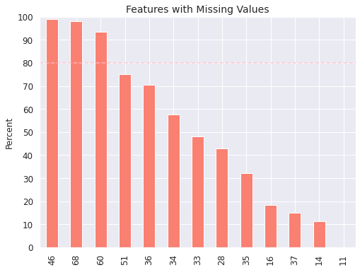

```
Number of missing values features: 13
cols_missing_high = ['Medical_History_10', 'Medical_History_32', 'Medical_History_24']
cols_missing_low = ['Medical_History_15', 'Family_Hist_5', 'Family_Hist_3', 'Family_Hist_2', 'Insurance_History_5', 'Family_Hist_4', 'Employment_Info_6', 'Medical_History_1', 'Employment_Info_4', 'Employment_Info_1']
```

|  | Feature | Type | Count | Missing | Zeros | Unique | MissingPct | ZerosPct | count | mean | std | min | 25% | 50% | 75% | max |
| --- | --- | --- | --- | --- | --- | --- | --- | --- | --- | --- | --- | --- | --- | --- | --- | --- |
| 46 | Medical_History_10 | float64 | 59381 | 58824 | 75 | 103 | 99.060000 | 0.130000 | 557.000000 | 141.118492 | 107.759559 | 0.000000 | 8.000000 | 229.000000 | 240.000000 | 240.000000 |
| 68 | Medical_History_32 | float64 | 59381 | 58274 | 744 | 95 | 98.140000 | 1.250000 | 1107.000000 | 11.965673 | 38.718774 | 0.000000 | 0.000000 | 0.000000 | 2.000000 | 240.000000 |
| 60 | Medical_History_24 | float64 | 59381 | 55580 | 769 | 227 | 93.600000 | 1.300000 | 3801.000000 | 50.635622 | 78.149069 | 0.000000 | 1.000000 | 8.000000 | 64.000000 | 240.000000 |
| 51 | Medical_History_15 | float64 | 59381 | 44596 | 2135 | 241 | 75.100000 | 3.600000 | 14785.000000 | 123.760974 | 98.516206 | 0.000000 | 17.000000 | 117.000000 | 240.000000 | 240.000000 |
| 36 | Family_Hist_5 | float64 | 59381 | 41811 | 3 | 90 | 70.410000 | 0.010000 | 17570.000000 | 0.484635 | 0.129200 | 0.000000 | 0.401786 | 0.508929 | 0.580357 | 1.000000 |
| 34 | Family_Hist_3 | float64 | 59381 | 34241 | 4 | 90 | 57.660000 | 0.010000 | 25140.000000 | 0.497737 | 0.140187 | 0.000000 | 0.401961 | 0.519608 | 0.598039 | 1.000000 |
| 33 | Family_Hist_2 | float64 | 59381 | 28656 | 1 | 68 | 48.260000 | 0.000000 | 30725.000000 | 0.474550 | 0.154959 | 0.000000 | 0.362319 | 0.463768 | 0.579710 | 1.000000 |
| 28 | Insurance_History_5 | float64 | 59381 | 25396 | 19 | 2265 | 42.770000 | 0.030000 | 33985.000000 | 0.001733 | 0.007338 | 0.000000 | 0.000400 | 0.000973 | 0.002000 | 1.000000 |
| 35 | Family_Hist_4 | float64 | 59381 | 19184 | 9 | 68 | 32.310000 | 0.020000 | 40197.000000 | 0.444890 | 0.163012 | 0.000000 | 0.323944 | 0.422535 | 0.563380 | 0.943662 |
| 16 | Employment_Info_6 | float64 | 59381 | 10854 | 4042 | 992 | 18.280000 | 6.810000 | 48527.000000 | 0.361469 | 0.349551 | 0.000000 | 0.060000 | 0.250000 | 0.550000 | 1.000000 |
| 37 | Medical_History_1 | float64 | 59381 | 8889 | 4789 | 171 | 14.970000 | 8.060000 | 50492.000000 | 7.962172 | 13.027697 | 0.000000 | 2.000000 | 4.000000 | 9.000000 | 240.000000 |
| 14 | Employment_Info_4 | float64 | 59381 | 6779 | 44659 | 871 | 11.420000 | 75.210000 | 52602.000000 | 0.006283 | 0.032816 | 0.000000 | 0.000000 | 0.000000 | 0.000000 | 1.000000 |
| 11 | Employment_Info_1 | float64 | 59381 | 19 | 3688 | 1936 | 0.030000 | 6.210000 | 59362.000000 | 0.077582 | 0.082347 | 0.000000 | 0.035000 | 0.060000 | 0.100000 | 1.000000 |

```python
df.bp.missing()
```

```python
# remove features with >= 80% missing values
cols_missing_high = ['Medical_History_10',
                     'Medical_History_32',
                     'Medical_History_24']
df = df.drop(cols_missing_high,axis=1)
```

```python
 cols_missing_low = ['Medical_History_15', 'Family_Hist_5',
                     'Family_Hist_3', 'Family_Hist_2',
                     'Insurance_History_5', 'Family_Hist_4',
                     'Employment_Info_6', 'Medical_History_1',
                     'Employment_Info_4', 'Employment_Info_1']
```

```python
df = df.fillna(-1)
```

```python
df.isna().sum().sum()
```

```
0
```

# Categorical Encoding

The following variables are all categorical (nominal):

Product_Info_1, Product_Info_2, Product_Info_3, Product_Info_5, Product_Info_6, Product_Info_7, Employment_Info_2, Employment_Info_3, Employment_Info_5, InsuredInfo_1, InsuredInfo_2, InsuredInfo_3, InsuredInfo_4, InsuredInfo_5, InsuredInfo_6, InsuredInfo_7, Insurance_History_1, Insurance_History_2, Insurance_History_3, Insurance_History_4, Insurance_History_7, Insurance_History_8, Insurance_History_9, Family_Hist_1, Medical_History_2, Medical_History_3, Medical_History_4, Medical_History_5, Medical_History_6, Medical_History_7, Medical_History_8, Medical_History_9, Medical_History_11, Medical_History_12, Medical_History_13, Medical_History_14, Medical_History_16, Medical_History_17, Medical_History_18, Medical_History_19, Medical_History_20, Medical_History_21, Medical_History_22, Medical_History_23, Medical_History_25, Medical_History_26, Medical_History_27, Medical_History_28, Medical_History_29, Medical_History_30, Medical_History_31, Medical_History_33, Medical_History_34, Medical_History_35, Medical_History_36, Medical_History_37, Medical_History_38, Medical_History_39, Medical_History_40, Medical_History_41

The following variables are continuous:

Product_Info_4, Ins_Age, Ht, Wt, BMI, Employment_Info_1, Employment_Info_4, Employment_Info_6, Insurance_History_5, Family_Hist_2, Family_Hist_3, Family_Hist_4, Family_Hist_5

The following variables are discrete:

Medical_History_1, Medical_History_10, Medical_History_15, Medical_History_24, Medical_History_32

Medical_Keyword_1-48 are dummy variables.

Quantitative variables can be classified as discrete or continuous.

**Categorical variable definition**

Categorical variables contain a finite number of categories or distinct groups. Categorical data might not have a logical order. For example, categorical predictors include gender, material type, and payment method.

**Discrete variable definition**  
Discrete variables are numeric variables that have a countable number of values between any two values. A discrete variable is always numeric. For example, the number of customer complaints or the number of flaws or defects.

```python
# df.dtypes.loc[lambda x: x=='object']
```

```python
df.select_dtypes('object').head(2)
```

|  | Product_Info_2_char | Age_cat | Ht_cat | Wt_cat | BMI_cat |
| --- | --- | --- | --- | --- | --- |
| 0 | D | high | low | low | low |
| 1 | A | low | low | low | low |

```python
df['Product_Info_2_char'].nunique() # for small number we can use OHE
```

```
5
```

```python
cols_discrete = ['Medical_History_1', 'Medical_History_10',
                     'Medical_History_15', 'Medical_History_24',
                     'Medical_History_32']

cols_discrete = [i for i in cols_discrete if i not in cols_missing_high]
df[cols_discrete].head()
```

|  | Medical_History_1 | Medical_History_15 |
| --- | --- | --- |
| 0 | 4.0 | 240.0 |
| 1 | 5.0 | 0.0 |
| 2 | 10.0 | -1.0 |
| 3 | 0.0 | -1.0 |
| 4 | -1.0 | -1.0 |

```python
df[cols_discreet].nunique()
```

```
Medical_History_1     172
Medical_History_15    242
dtype: int64
```

```python
# df_copy = df.copy()
```

```python
col = 'Medical_History_1'
# df[col].value_counts()
```

```python
col = 'Medical_History_1'
top_col = df[col].value_counts()[lambda x: x> 10].index

df.loc[~df[col].isin(top_col),col] = -2
```

```python
col = 'Medical_History_15'
# df[col].value_counts().head(200).reset_index()
```

```python
# the value count is steadily decreasing, there is no obvious cut-off point.
```

```python
cols_cat = ['Product_Info_1', 'Product_Info_2',
            'Product_Info_3', 'Product_Info_5',
            'Product_Info_6', 'Product_Info_7',
            'Employment_Info_2', 'Employment_Info_3',
            'Employment_Info_5', 'InsuredInfo_1',
            'InsuredInfo_2', 'InsuredInfo_3',
            'InsuredInfo_4', 'InsuredInfo_5',
            'InsuredInfo_6', 'InsuredInfo_7',
            'Insurance_History_1', 'Insurance_History_2',
            'Insurance_History_3', 'Insurance_History_4',
            'Insurance_History_7', 'Insurance_History_8',
            'Insurance_History_9', 'Family_Hist_1',
            'Medical_History_2', 'Medical_History_3',
            'Medical_History_4', 'Medical_History_5',
            'Medical_History_6', 'Medical_History_7',
            'Medical_History_8', 'Medical_History_9',
            'Medical_History_11', 'Medical_History_12',
            'Medical_History_13', 'Medical_History_14',
            'Medical_History_16', 'Medical_History_17',
            'Medical_History_18', 'Medical_History_19',
            'Medical_History_20', 'Medical_History_21',
            'Medical_History_22', 'Medical_History_23',
            'Medical_History_25', 'Medical_History_26',
            'Medical_History_27', 'Medical_History_28',
            'Medical_History_29', 'Medical_History_30',
            'Medical_History_31', 'Medical_History_33',
            'Medical_History_34', 'Medical_History_35',
            'Medical_History_36', 'Medical_History_37',
            'Medical_History_38', 'Medical_History_39',
            'Medical_History_40', 'Medical_History_41']

cols_cat = [i for i in cols_cat if i not in ['Product_Info_2']]
# df[cols_cat].nunique()
```

```python
df[cols_cat].nunique().loc[lambda x: x>10]
```

```
Product_Info_3        34
Employment_Info_2     36
InsuredInfo_3         11
Medical_History_2    579
dtype: int64
```

```python
# df['Medical_History_2'].value_counts().head(200)
```

```python
col = 'Medical_History_2'
top_col = df[col].value_counts()[lambda x: x> 100].index
df.loc[~df[col].isin(top_col),col] = -2
```

```python
# df.nunique().loc[lambda x: x>90]
```

```python
cols = df.nunique().loc[lambda x: x>90].index.to_list()
# df[cols].dtypes
df[cols].head(2)
```

|  | Id | Product_Info_4 | Wt | BMI | Employment_Info_1 | Employment_Info_4 | Employment_Info_6 | Insurance_History_5 | Family_Hist_3 | Family_Hist_5 | Medical_History_15 | Wt_sq | BMI_sq | Wt_cu | BMI_cu | Age_Ht | Age_Wt | Age_BMI | Medical_Keyword_skew | Medical_Keyword_kurtosis |
| --- | --- | --- | --- | --- | --- | --- | --- | --- | --- | --- | --- | --- | --- | --- | --- | --- | --- | --- | --- | --- |
| 0 | 2 | 0.076923 | 0.148536 | 0.323008 | 0.028 | 0.0 | -1.0000 | 0.000667 | 0.598039 | 0.526786 | 240.0 | 0.022063 | 0.104334 | 0.003277 | 0.033701 | 0.373406 | 0.095329 | 0.207304 | 0.0 | 0.0 |
| 1 | 5 | 0.076923 | 0.131799 | 0.272288 | 0.000 | 0.0 | 0.0018 | 0.000133 | -1.000000 | -1.000000 | 0.0 | 0.017371 | 0.074141 | 0.002289 | 0.020188 | 0.035821 | 0.007869 | 0.016256 | 0.0 | 0.0 |

## One hot encode categorical features

```python
risk_cat = ['Age_cat', 'Ht_cat', 'Wt_cat', 'BMI_cat']
cols_cat_all = cols_cat + cols_discreet + risk_cat + ['Product_Info_2_char']
print(f"Number of categorical features: {len(cols_cat_all)}")
```

```
Number of categorical features: 66
```

```python
# df[cols_cat].nunique()
```

```python
print(f"Shape of df before encoding: {df.shape}")
```

```
Shape of df before encoding: (59381, 154)
```

```python
df_encoded = pd.get_dummies(df,columns=cols_cat_all,drop_first=True)
```

```python
print(f"Shape of df after encoding: {df_encoded.shape}")
```

```
Shape of df after encoding: (59381, 641)
```

```python
df_encoded.select_dtypes('object').shape
```

```
(59381, 0)
```

```python
df_encoded.sum().sum() # this needs to a number
```

```
2351133889.742992
```

# Normalize Numerical Features

Here we already have normalized numerical features. I will not log transform and normalize the numerical features.

# Correlations

```python
df.filter(regex='Resp').head(2)
```

|  | Response | Response8 |
| --- | --- | --- |
| 0 | 8 | 1 |
| 1 | 4 | 0 |

```python
df.head(2)
```

|  | Id | Product_Info_1 | Product_Info_3 | Product_Info_4 | Product_Info_5 | Product_Info_6 | Product_Info_7 | Ins_Age | Ht | Wt | BMI | Employment_Info_1 | Employment_Info_2 | Employment_Info_3 | Employment_Info_4 | Employment_Info_5 | Employment_Info_6 | InsuredInfo_1 | InsuredInfo_2 | InsuredInfo_3 | InsuredInfo_4 | InsuredInfo_5 | InsuredInfo_6 | InsuredInfo_7 | Insurance_History_1 | Insurance_History_2 | Insurance_History_3 | Insurance_History_4 | Insurance_History_5 | … |
| --- | --- | --- | --- | --- | --- | --- | --- | --- | --- | --- | --- | --- | --- | --- | --- | --- | --- | --- | --- | --- | --- | --- | --- | --- | --- | --- | --- | --- | --- | --- |
| 0 | 2 | 1 | 10 | 0.076923 | 2 | 1 | 1 | 0.641791 | 0.581818 | 0.148536 | 0.323008 | 0.028 | 12 | 1 | 0.0 | 3 | -1.0000 | 1 | 2 | 6 | 3 | 1 | 2 | 1 | 1 | 1 | 3 | 1 | 0.000667 | … |
| 1 | 5 | 1 | 26 | 0.076923 | 2 | 3 | 1 | 0.059701 | 0.600000 | 0.131799 | 0.272288 | 0.000 | 1 | 3 | 0.0 | 2 | 0.0018 | 1 | 2 | 6 | 3 | 1 | 2 | 1 | 2 | 1 | 3 | 1 | 0.000133 | … |

```python
cols_drop = ['Id','Response','Response8']

(df.drop(cols_drop,axis=1)
  .corrwith(df[target8]).abs()
  .to_frame()
  .sort_values([0],ascending=False).T)
```

|  | BMI | Wt | BMI_sq | risk_extreme | Wt_sq | risk_at_least_one_high | BMI_cu | Age_Wt | Age_BMI | Wt_cu | Medical_History_23 | Medical_Keyword_15 | Medical_Keyword_std | Medical_Keyword_mean | Medical_Keyword_count | Medical_History_4 | Medical_Keyword_max | risk_at_least_one_low | Age_Ht | Ins_Age | Ins_Age_sq | Ins_Age_cu | InsuredInfo_6 | Medical_Keyword_skew | Product_Info_4 | Family_Hist_2 | Family_Hist_3 | Family_Hist_5 | Medical_Keyword_3 | … |
| --- | --- | --- | --- | --- | --- | --- | --- | --- | --- | --- | --- | --- | --- | --- | --- | --- | --- | --- | --- | --- | --- | --- | --- | --- | --- | --- | --- | --- | --- | --- |
| 0 | 0.433625 | 0.41403 | 0.403152 | 0.396987 | 0.383789 | 0.361736 | 0.35841 | 0.356771 | 0.354639 | 0.333922 | 0.326246 | 0.316473 | 0.298751 | 0.279796 | 0.279796 | 0.276195 | 0.264136 | 0.245505 | 0.238643 | 0.221867 | 0.21643 | 0.204544 | 0.195071 | 0.177664 | 0.17469 | 0.170483 | 0.164334 | 0.162137 | 0.154817 | … |

# Create features using unsupervied clustering algorithms

```python
cols_drop = ['Id','Response','Response8']
cols_high_corr = (df.drop(cols_drop,axis=1)
                    .corrwith(df[target8]).abs()
                    .sort_values(ascending=False)
                    .head(20)
                    .index.to_list()
                    )

print(cols_high_corr)
```

```
['BMI', 'Wt', 'BMI_sq', 'risk_extreme', 'Wt_sq', 'risk_at_least_one_high', 'BMI_cu', 'Age_Wt', 'Age_BMI', 'Wt_cu', 'Medical_History_23', 'Medical_Keyword_15', 'Medical_Keyword_std', 'Medical_Keyword_mean', 'Medical_Keyword_count', 'Medical_History_4', 'Medical_Keyword_max', 'risk_at_least_one_low', …
```

```python
df_high_corr = df[cols_high_corr]
df_high_corr.head(2)
```

|  | BMI | Wt | BMI_sq | risk_extreme | Wt_sq | risk_at_least_one_high | BMI_cu | Age_Wt | Age_BMI | Wt_cu | Medical_History_23 | Medical_Keyword_15 | Medical_Keyword_std | Medical_Keyword_mean | Medical_Keyword_count | Medical_History_4 | Medical_Keyword_max | risk_at_least_one_low | Age_Ht | Ins_Age |
| --- | --- | --- | --- | --- | --- | --- | --- | --- | --- | --- | --- | --- | --- | --- | --- | --- | --- | --- | --- | --- |
| 0 | 0.323008 | 0.148536 | 0.104334 | 1 | 0.022063 | 1 | 0.033701 | 0.095329 | 0.207304 | 0.003277 | 3 | 0 | 0.0 | 0.0 | 0 | 1 | 0 | 1 | 0.373406 | 0.641791 |
| 1 | 0.272288 | 0.131799 | 0.074141 | 0 | 0.017371 | 0 | 0.020188 | 0.007869 | 0.016256 | 0.002289 | 3 | 0 | 0.0 | 0.0 | 0 | 1 | 0 | 1 | 0.035821 | 0.059701 |

## Gaussian Mixture

```python
from sklearn.mixture import GaussianMixture
```

```python
model = GaussianMixture(n_components=len(cols_high_corr), random_state=SEED, reg_covar=1e-3)
model.fit(df_high_corr)

df['cluster_gmix20'] = model.predict(df_high_corr)
```

```python
df.filter(regex='cluster').head(2)
```

|  | cluster_gmix20 |
| --- | --- |
| 0 | 5 |
| 1 | 10 |

```python
gc.collect()
```

```
4178
```

## Birch Clustering

```python
from sklearn.cluster import Birch
```

```python
model = Birch(n_clusters=len(cols_high_corr))
model
```

```
Birch(branching_factor=50, compute_labels=True, copy=True, n_clusters=20,
      threshold=0.5)
```

```python
df['cluster_birch20'] = model.fit(df_high_corr).labels_

df.filter(regex='cluster').head(2)
```

|  | cluster_gmix20 | cluster_birch20 |
| --- | --- | --- |
| 0 | 5 | 13 |
| 1 | 10 | 13 |

```python
gc.collect()
```

```
0
```

## Two features Birch Clusterings

```python
model_birch2 = Birch(n_clusters=2)
model_birch2
```

```
Birch(branching_factor=50, compute_labels=True, copy=True, n_clusters=2,
      threshold=0.5)
```

```python
bmi_cols = ['Ins_Age','Wt','Ht',
            'Medical_Keyword_15',
            'Medical_Keyword_count']

for col in bmi_cols:
    dfx = df[['BMI',col]].reset_index(drop=True)
    dfx.columns = ['BMI',col]
    df[f'cluster2_BMI_vs_{col}'] = model_birch2.fit(dfx).labels_
```

```python
cols_first = ['Medical_History_4','Product_Info_4','Age_BMI','Age_BMI']
cols_second = ['Medical_History_23','InsuredInfo_6','Age_Ht','Age_Wt']

for col1, col2 in zip(cols_first, cols_second):
    dfx = df[[col1,col2]].reset_index(drop=True)
    dfx.columns = [col1,col2]

    df[f'cluster2_{col1}_vs_{col2}'] = model_birch2.fit(dfx).labels_
```

```python
cols_risk_cluster = ['risk_at_least_one_low',
                     'risk_at_least_one_high',
                     'risk_extreme']

cols_risk_cluster_second = ['Medical_History_23', 'Medical_History_4',
                    'Medical_Keyword_15','Medical_Keyword_count',
                    'Product_Info_4','InsuredInfo_6','BMI']

for col1 in cols_risk_cluster:
    for col2 in cols_risk_cluster_second:
        dfx = df[[col1,col2]].reset_index(drop=True)
        dfx.columns = [col1,col2]
        df[f'cluster2_{col1}_vs_{col2}'] = model_birch2.fit(dfx).labels_
```

```python
df.filter(regex='cluster').head(2)
```

|  | cluster_gmix20 | cluster_birch20 | cluster2_BMI_vs_Ins_Age | cluster2_BMI_vs_Wt | cluster2_BMI_vs_Ht | cluster2_BMI_vs_Medical_Keyword_15 | cluster2_BMI_vs_Medical_Keyword_count | cluster2_Medical_History_4_vs_Medical_History_23 | cluster2_Product_Info_4_vs_InsuredInfo_6 | cluster2_Age_BMI_vs_Age_Ht | cluster2_Age_BMI_vs_Age_Wt | cluster2_risk_at_least_one_low_vs_Medical_History_23 | cluster2_risk_at_least_one_low_vs_Medical_History_4 | cluster2_risk_at_least_one_low_vs_Medical_Keyword_15 | cluster2_risk_at_least_one_low_vs_Medical_Keyword_count | cluster2_risk_at_least_one_low_vs_Product_Info_4 | cluster2_risk_at_least_one_low_vs_InsuredInfo_6 | cluster2_risk_at_least_one_low_vs_BMI | cluster2_risk_at_least_one_high_vs_Medical_History_23 | cluster2_risk_at_least_one_high_vs_Medical_History_4 | cluster2_risk_at_least_one_high_vs_Medical_Keyword_15 | cluster2_risk_at_least_one_high_vs_Medical_Keyword_count | cluster2_risk_at_least_one_high_vs_Product_Info_4 | cluster2_risk_at_least_one_high_vs_InsuredInfo_6 | cluster2_risk_at_least_one_high_vs_BMI | cluster2_risk_extreme_vs_Medical_History_23 | cluster2_risk_extreme_vs_Medical_History_4 | cluster2_risk_extreme_vs_Medical_Keyword_15 | cluster2_risk_extreme_vs_Medical_Keyword_count | … |
| --- | --- | --- | --- | --- | --- | --- | --- | --- | --- | --- | --- | --- | --- | --- | --- | --- | --- | --- | --- | --- | --- | --- | --- | --- | --- | --- | --- | --- | --- | --- |
| 0 | 5 | 13 | 0 | 0 | 0 | 0 | 1 | 1 | 1 | 0 | 0 | 1 | 1 | 1 | 1 | 1 | 1 | 1 | 1 | 1 | 0 | 1 | 0 | 1 | 1 | 1 | 1 | 1 | 1 | … |
| 1 | 10 | 13 | 0 | 0 | 0 | 0 | 1 | 1 | 1 | 0 | 0 | 1 | 1 | 1 | 1 | 1 | 1 | 1 | 1 | 1 | 0 | 1 | 1 | 1 | 0 | 1 | 1 | 1 | 1 | … |

```python
# check if the feature has only one value
df.filter(regex='cluster').nunique().loc[lambda x: x==1]
```

```
cluster2_BMI_vs_Ins_Age               1
cluster2_BMI_vs_Wt                    1
cluster2_BMI_vs_Ht                    1
cluster2_BMI_vs_Medical_Keyword_15    1
cluster2_Age_BMI_vs_Age_Ht            1
cluster2_Age_BMI_vs_Age_Wt            1
dtype: int64
```

```python
cols_drop = df.filter(regex='cluster').nunique().loc[lambda x: x==1].index.to_list()
print(cols_drop)
```

```
['cluster2_BMI_vs_Ins_Age', 'cluster2_BMI_vs_Wt', 'cluster2_BMI_vs_Ht', 'cluster2_BMI_vs_Medical_Keyword_15', 'cluster2_Age_BMI_vs_Age_Ht', 'cluster2_Age_BMI_vs_Age_Wt']
```

```python
df = df.drop(cols_drop,axis=1)
df.nunique().loc[lambda x: x==1]
```

```
Series([], dtype: int64)
```

# Remove Highly Correlated Features

```python
import json
```

```python
df.shape
```

```
(59381, 180)
```

```python
def get_high_correlated_features(df, thr=0.95):
    cols_corr = set()
    df_corr = df.corr()
    for i in range(len(df_corr.columns)):
        for j in range(i):
            if (df_corr.iloc[i, j] >= thr) and (df_corr.columns[j] not in cols_corr):
                colname = df_corr.columns[i]
                cols_corr.add(colname)

    return cols_corr
```

```python
cols_high_corr = get_high_correlated_features(df,thr=0.95)
print(cols_high_corr)
```

```
{'cluster2_risk_extreme_vs_Medical_History_4', 'cluster2_risk_at_least_one_high_vs_BMI', 'cluster2_risk_at_least_one_low_vs_Medical_History_4', 'Medical_History_36', 'cluster2_risk_extreme_vs_InsuredInfo_6', 'BMI_sq', 'Insurance_History_9', 'cluster2_risk_at_least_one_low_vs_InsuredInfo_6', 'Age_BMI…
```

```python
print(len(cols_corr))
```

```
29
```

```python
out_json = out_dir + 'Prudential/correlated_features.json'
print(out_json)
```

```
drive/My Drive/Colab Notebooks/outputs/Prudential/correlated_features.json
```

```python
with open(out_json,'w') as fo:
    json.dump(out_json,fo)
```

```python
df = df.drop(cols_high_corr,axis=1)
df.shape
```

```
(59381, 151)
```